# 11285410

# Argicultural Department

```python
#required Python libraries


import numpy as np
import pandas as pd

import matplotlib.pyplot as plt
%matplotlib inline

import warnings
warnings.filterwarnings('ignore')
```

```python
dataset = pd.read_csv('red_wine.csv')
```

```python
dataset
```

|  | fixed acidity | volatile acidity | citric acid | residual sugar | chlorides | free sulfur dioxide | total sulfur dioxide | density | pH | sulphates | alcohol | quality |
| --- | --- | --- | --- | --- | --- | --- | --- | --- | --- | --- | --- | --- |
| 0 | 7.4 | 0.700 | 0.00 | 1.9 | 0.076 | 11.0 | 34.0 | 0.99780 | 3.51 | 0.56 | 9.4 | 5.0 |
| 1 | 7.8 | 0.880 | 0.00 | 2.6 | 0.098 | 25.0 | 67.0 | 0.99680 | 3.20 | 0.68 | 9.8 | 5.0 |
| 2 | 7.8 | 0.760 | 0.04 | 2.3 | 0.092 | 15.0 | 54.0 | 0.99700 | 3.26 | 0.65 | 9.8 | 5.0 |
| 3 | 11.2 | 0.280 | 0.56 | 1.9 | 0.075 | 17.0 | 60.0 | 0.99800 | 3.16 | 0.58 | 9.8 | 6.0 |
| 4 | 7.4 | 0.700 | 0.00 | 1.9 | 0.076 | 11.0 | 34.0 | 0.99780 | 3.51 | 0.56 | 9.4 | 5.0 |
| ... | ... | ... | ... | ... | ... | ... | ... | ... | ... | ... | ... | ... |
| 1594 | 6.2 | 0.600 | 0.08 | 2.0 | 0.090 | 32.0 | 44.0 | 0.99490 | 3.45 | 0.58 | 10.5 | 5.0 |
| 1595 | 5.9 | 0.550 | 0.10 | 2.2 | 0.062 | 39.0 | 51.0 | 0.99512 | 3.52 | 0.76 | 11.2 | 6.0 |
| 1596 | 6.3 | 0.510 | 0.13 | 2.3 | 0.076 | 29.0 | 40.0 | 0.99574 | 3.42 | 0.75 | 11.0 | 6.0 |
| 1597 | 5.9 | 0.645 | 0.12 | 2.0 | 0.075 | 32.0 | 44.0 | 0.99547 | 3.57 | 0.71 | 10.2 | 5.0 |
| 1598 | 6.0 | 0.310 | 0.47 | 3.6 | 0.067 | 18.0 | 42.0 | 0.99549 | 3.39 | 0.66 | 11.0 | 6.0 |

1599 rows × 12 columns

```python
dataset.head(10)
```

|  | fixed acidity | volatile acidity | citric acid | residual sugar | chlorides | free sulfur dioxide | total sulfur dioxide | density | pH | sulphates | alcohol | quality |
| --- | --- | --- | --- | --- | --- | --- | --- | --- | --- | --- | --- | --- |
| 0 | 7.4 | 0.70 | 0.00 | 1.9 | 0.076 | 11.0 | 34.0 | 0.9978 | 3.51 | 0.56 | 9.4 | 5.0 |
| 1 | 7.8 | 0.88 | 0.00 | 2.6 | 0.098 | 25.0 | 67.0 | 0.9968 | 3.20 | 0.68 | 9.8 | 5.0 |
| 2 | 7.8 | 0.76 | 0.04 | 2.3 | 0.092 | 15.0 | 54.0 | 0.9970 | 3.26 | 0.65 | 9.8 | 5.0 |
| 3 | 11.2 | 0.28 | 0.56 | 1.9 | 0.075 | 17.0 | 60.0 | 0.9980 | 3.16 | 0.58 | 9.8 | 6.0 |
| 4 | 7.4 | 0.70 | 0.00 | 1.9 | 0.076 | 11.0 | 34.0 | 0.9978 | 3.51 | 0.56 | 9.4 | 5.0 |
| 5 | 7.4 | 0.66 | 0.00 | 1.8 | 0.075 | 13.0 | 40.0 | 0.9978 | 3.51 | 0.56 | 9.4 | 5.0 |
| 6 | 7.9 | 0.60 | 0.06 | 1.6 | NaN | 15.0 | 59.0 | 0.9964 | 3.30 | 0.46 | 9.4 | 5.0 |
| 7 | 7.3 | 0.65 | 0.00 | 1.2 | 0.065 | 15.0 | 21.0 | 0.9946 | 3.39 | 0.47 | 10.0 | 7.0 |
| 8 | 7.8 | 0.58 | 0.02 | 2.0 | 0.073 | 9.0 | 18.0 | 0.9968 | 3.36 | 0.57 | 9.5 | 7.0 |
| 9 | 7.5 | 0.50 | 0.36 | 6.1 | 0.071 | 17.0 | 102.0 | 0.9978 | 3.35 | 0.80 | 10.5 | 5.0 |

```python
dataset.tail(20)
```

|  | fixed acidity | volatile acidity | citric acid | residual sugar | chlorides | free sulfur dioxide | total sulfur dioxide | density | pH | sulphates | alcohol | quality |
| --- | --- | --- | --- | --- | --- | --- | --- | --- | --- | --- | --- | --- |
| 1579 | 6.2 | 0.560 | 0.09 | 1.7 | 0.053 | 24.0 | 32.0 | 0.99402 | 3.54 | 0.60 | 11.3 | 5.0 |
| 1580 | 7.4 | 0.350 | 0.33 | 2.4 | 0.068 | 9.0 | 26.0 | 0.99470 | 3.36 | 0.60 | 11.9 | 6.0 |
| 1581 | 6.2 | 0.560 | 0.09 | 1.7 | 0.053 | 24.0 | 32.0 | 0.99402 | 3.54 | 0.60 | 11.3 | 5.0 |
| 1582 | 6.1 | 0.715 | 0.10 | 2.6 | 0.053 | 13.0 | 27.0 | 0.99362 | 3.57 | 0.50 | 11.9 | 5.0 |
| 1583 | 6.2 | 0.460 | 0.29 | 2.1 | 0.074 | 32.0 | 98.0 | 0.99578 | 3.33 | 0.62 | 9.8 | 5.0 |
| 1584 | 6.7 | 0.320 | 0.44 | 2.4 | 0.061 | 24.0 | 34.0 | 0.99484 | 3.29 | 0.80 | 11.6 | 7.0 |
| 1585 | 7.2 | 0.390 | 0.44 | 2.6 | 0.066 | 22.0 | 48.0 | 0.99494 | 3.30 | 0.84 | 11.5 | 6.0 |
| 1586 | 7.5 | 0.310 | 0.41 | 2.4 | 0.065 | 34.0 | 60.0 | 0.99492 | 3.34 | 0.85 | 11.4 | 6.0 |
| 1587 | 5.8 | 0.610 | 0.11 | 1.8 | 0.066 | 18.0 | 28.0 | 0.99483 | 3.55 | 0.66 | 10.9 | 6.0 |
| 1588 | 7.2 | 0.660 | 0.33 | 2.5 | 0.068 | 34.0 | 102.0 | 0.99414 | 3.27 | 0.78 | 12.8 | 6.0 |
| 1589 | 6.6 | 0.725 | 0.20 | 7.8 | 0.073 | 29.0 | 79.0 | 0.99770 | 3.29 | 0.54 | 9.2 | 5.0 |
| 1590 | 6.3 | 0.550 | 0.15 | 1.8 | 0.077 | 26.0 | 35.0 | 0.99314 | 3.32 | 0.82 | 11.6 | 6.0 |
| 1591 | 5.4 | 0.740 | 0.09 | 1.7 | 0.089 | 16.0 | 26.0 | 0.99402 | 3.67 | 0.56 | 11.6 | 6.0 |
| 1592 | 6.3 | 0.510 | 0.13 | 2.3 | 0.076 | 29.0 | 40.0 | 0.99574 | 3.42 | 0.75 | 11.0 | 6.0 |
| 1593 | 6.8 | 0.620 | 0.08 | 1.9 | 0.068 | 28.0 | 38.0 | 0.99651 | 3.42 | 0.82 | 9.5 | 6.0 |
| 1594 | 6.2 | 0.600 | 0.08 | 2.0 | 0.090 | 32.0 | 44.0 | 0.99490 | 3.45 | 0.58 | 10.5 | 5.0 |
| 1595 | 5.9 | 0.550 | 0.10 | 2.2 | 0.062 | 39.0 | 51.0 | 0.99512 | 3.52 | 0.76 | 11.2 | 6.0 |
| 1596 | 6.3 | 0.510 | 0.13 | 2.3 | 0.076 | 29.0 | 40.0 | 0.99574 | 3.42 | 0.75 | 11.0 | 6.0 |
| 1597 | 5.9 | 0.645 | 0.12 | 2.0 | 0.075 | 32.0 | 44.0 | 0.99547 | 3.57 | 0.71 | 10.2 | 5.0 |
| 1598 | 6.0 | 0.310 | 0.47 | 3.6 | 0.067 | 18.0 | 42.0 | 0.99549 | 3.39 | 0.66 | 11.0 | 6.0 |

```python
dataset.info()
```

```
<class 'pandas.core.frame.DataFrame'>
RangeIndex: 1599 entries, 0 to 1598
Data columns (total 12 columns):
 #   Column                Non-Null Count  Dtype
---  ------                --------------  -----
 0   fixed acidity         1598 non-null   float64
 1   volatile acidity      1598 non-null   float64
 2   citric acid           1599 non-null   float64
 3   residual sugar        1599 non-null   float64
 4   chlorides             1595 non-null   float64
 5   free sulfur dioxide   1598 non-null   float64
 6   total sulfur dioxide  1599 non-null   float64
 7   density               1598 non-null   float64
 8   pH                    1599 non-null   float64
 9   sulphates             1599 non-null   float64
 10  alcohol               1599 non-null   float64
 11  quality               1598 non-null   float64
dtypes: float64(12)
memory usage: 150.0 KB
```

```python
dataset.describe()
```

|  | fixed acidity | volatile acidity | citric acid | residual sugar | chlorides | free sulfur dioxide | total sulfur dioxide | density | pH | sulphates | alcohol | quality |
| --- | --- | --- | --- | --- | --- | --- | --- | --- | --- | --- | --- | --- |
| count | 1598.000000 | 1598.000000 | 1599.000000 | 1599.000000 | 1595.000000 | 1598.000000 | 1599.000000 | 1598.000000 | 1599.000000 | 1599.000000 | 1599.000000 | 1598.000000 |
| mean | 8.318335 | 0.527747 | 0.270976 | 2.538806 | 0.087476 | 15.867334 | 46.467792 | 0.996746 | 3.311113 | 0.658149 | 10.422983 | 5.635795 |
| std | 1.740863 | 0.179092 | 0.194801 | 1.409928 | 0.047117 | 10.459029 | 32.895324 | 0.001887 | 0.154386 | 0.169507 | 1.065668 | 0.807771 |
| min | 4.600000 | 0.120000 | 0.000000 | 0.900000 | 0.012000 | 1.000000 | 6.000000 | 0.990070 | 2.740000 | 0.330000 | 8.400000 | 3.000000 |
| 25% | 7.100000 | 0.390000 | 0.090000 | 1.900000 | 0.070000 | 7.000000 | 22.000000 | 0.995600 | 3.210000 | 0.550000 | 9.500000 | 5.000000 |
| 50% | 7.900000 | 0.520000 | 0.260000 | 2.200000 | 0.079000 | 14.000000 | 38.000000 | 0.996750 | 3.310000 | 0.620000 | 10.200000 | 6.000000 |
| 75% | 9.200000 | 0.640000 | 0.420000 | 2.600000 | 0.090000 | 21.000000 | 62.000000 | 0.997830 | 3.400000 | 0.730000 | 11.100000 | 6.000000 |
| max | 15.900000 | 1.580000 | 1.000000 | 15.500000 | 0.611000 | 72.000000 | 289.000000 | 1.003690 | 4.010000 | 2.000000 | 14.900000 | 8.000000 |

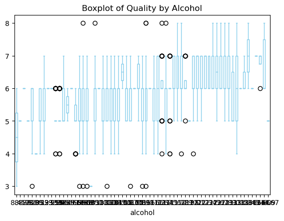

```python
# A boxplot for Boxplot of Quality by Alcohol
plt.figure(figsize=(12, 8))
dataset.boxplot(column='quality', by='alcohol', grid=False,color='skyblue')
plt.title('Boxplot of Quality by Alcohol')
plt.suptitle('')
plt.show()
```

# 1. Boxplot of Quality vs. Alcohol Content

- The boxplot visually depicts the relationship between wine quality and alcohol content.It suggests that wines with higher quality tend to have slightly higher alchole content

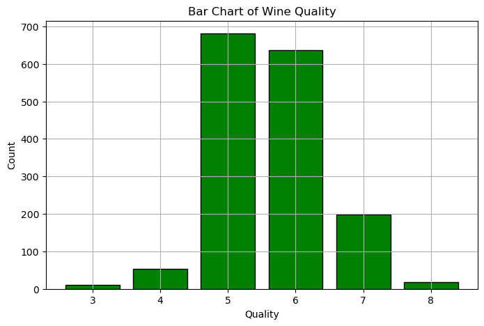

```python
# Bar chart of wine Quality using Matplotlib
plt.figure(figsize=(8, 5))
quality_counts = dataset['quality'].value_counts().sort_index()
plt.bar(quality_counts.index, quality_counts, color='green',edgecolor='black')
plt.title('Bar Chart of Wine Quality')
plt.xlabel('Quality')
plt.ylabel('Count')
plt.grid(True)
plt.show()
```

# 2. Bar Chart of Wine Quality

- The bar chart provides a count of wines for each quality rating. Most wines in the dataset have a quality rating of 5.

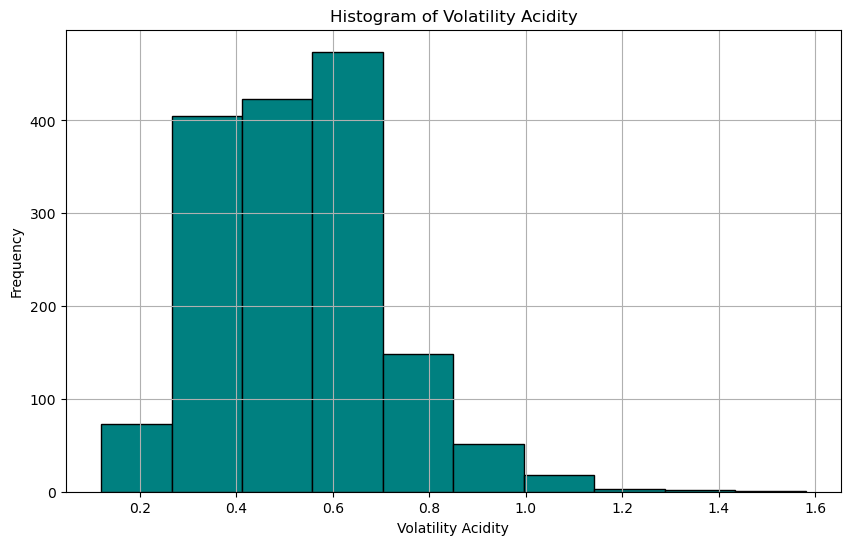

```python
plt.figure(figsize=(10, 6))
plt.hist(dataset['volatile acidity'], bins=10, color='Teal', edgecolor='black')
plt.title('Histogram of Volatility Acidity')
plt.xlabel('Volatility Acidity')
plt.ylabel('Frequency')
plt.grid(True)
plt.show()
```

# 3. Histogram of Volatility Acidity

- The histogram displays the distribution of Volatility Acidity values in the darkest. Most wines have a Volatility Acidity around 0.6

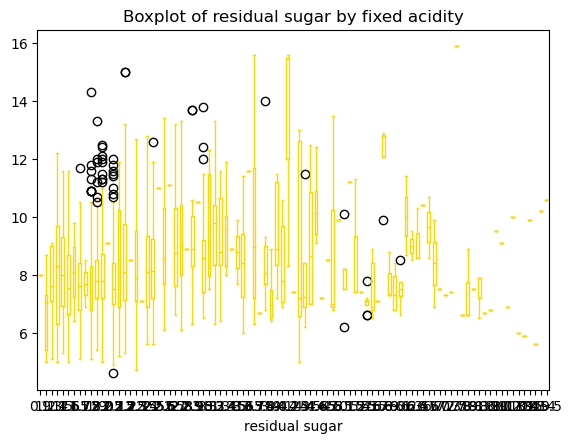

```python
# A boxplot for Boxplot of Quality by Alcohol
plt.figure(figsize=(12, 8))
dataset.boxplot(column='fixed acidity', by='residual sugar', grid=False,color='gold')
plt.title('Boxplot of residual sugar by fixed acidity')
plt.suptitle('')
plt.show()
```